# Relatório 09

Gustavo Cardoso

01 /07/2025

# 1 Objetivo

No relatório 9, temos como objetivo compreender o uso de blocos para reduzir a variabilidade experimental, ajustar a ANOVA para um experimento fatorial triplo em DBC, verificar a significância dos efeitos principais e interações envolvidas, identificar práticas eficazes para o controle da evaporação, e, por fim, responder as questões voltadas para a análise do relatório.

# 2 Compilado de códigos em R para reproduzir a análise

```
##                          Df Sum Sq Mean Sq F value   Pr(>F)
## bloco                     3    109      36   0.393   0.7587
## acabamento                2   3687    1844  19.948 3.98e-07 ***
## protecao                  2  13741    6870  74.336 7.67e-16 ***
## base                      1  22015   22015 238.200  < 2e-16 ***
## acabamento:protecao       4   1084     271   2.933   0.0294 *
## acabamento:base           2    355     177   1.920   0.1571
## protecao:base             2    430     215   2.324   0.1082
## acabamento:protecao:base  4    303      76   0.820   0.5183
## Residuals                51   4714      92
## ---
## Signif. codes:  0 '***' 0.001 '**' 0.01 '*' 0.05 '.' 0.1 ' ' 1
```

```
##   Tukey multiple comparisons of means
##     95% family-wise confidence level
##
## Fit: aov(formula = evap ~ bloco + acabamento * protecao * base, data = dados)
##
## $bloco
##            diff        lwr       upr     p adj
## 2-1  0.40000000  -8.110667  8.910667 0.9992956
## 3-1 -2.57222222 -11.082889  5.938445 0.8528490
## 4-1  0.33888889  -8.171778  8.849556 0.9995709
## 3-2 -2.97222222 -11.482889  5.538445 0.7902769
## 4-2 -0.06111111  -8.571778  8.449556 0.9999975
## 4-3  2.91111111  -5.599556 11.421778 0.8004240
##
## $acabamento
##                               diff         lwr      upr     p adj
## Liso-Escarificado        17.225000  10.5256729 23.92433 0.0000003
## Vassourado-Escarificado   5.795833  -0.9034938 12.49516 0.1023147
## Vassourado-Liso         -11.429167 -18.1284938 -4.72984 0.0004056
##
## $protecao
##                 diff       lwr       upr p adj
## Lona-CuraQ -15.42500 -22.12433 -8.725673 3e-06
## Sem-CuraQ   18.37083  11.67151 25.070160 1e-07
## Sem-Lona    33.79583  27.09651 40.495160 0e+00
##
## $base
##                 diff       lwr       upr p adj
## Solo-Brita -34.97222 -39.52132 -30.42312     0
##
## $`acabamento:protecao`
##                                          diff         lwr         upr     p adj
## Liso:CuraQ-Escarificado:CuraQ         15.7750   0.2081542  31.3418458 0.0447475
## Vassourado:CuraQ-Escarificado:CuraQ   11.3250  -4.2418458  26.8918458 0.3297757
## Escarificado:Lona-Escarificado:CuraQ  -8.5750 -24.1418458   6.9918458 0.6920868
## Liso:Lona-Escarificado:CuraQ          -0.3625 -15.9293458  15.2043458 1.0000000
## Vassourado:Lona-Escarificado:CuraQ   -10.2375 -25.8043458   5.3293458 0.4654724
## Escarificado:Sem-Escarificado:CuraQ   15.6000   0.0331542  31.1668458 0.0491287
## Liso:Sem-Escarificado:CuraQ           43.2875  27.7206542  58.8543458 0.0000000
## Vassourado:Sem-Escarificado:CuraQ     23.3250   7.7581542  38.8918458 0.0003820
```

[output cut: 375 more lines]

```
## Liso:Lona:Solo-Escarificado:Lona:Solo             32.5148805 0.9995653
## Vassourado:Lona:Solo-Escarificado:Lona:Solo       20.1398805 0.9999992
## Escarificado:Sem:Solo-Escarificado:Lona:Solo      45.1648805 0.2520023
## Liso:Sem:Solo-Escarificado:Lona:Solo              69.5898805 0.0000038
## Vassourado:Sem:Solo-Escarificado:Lona:Solo        51.7398805 0.0241432
## Vassourado:Lona:Solo-Liso:Lona:Solo               12.5898805 0.9263428
## Escarificado:Sem:Solo-Liso:Lona:Solo              37.6148805 0.9129314
## Liso:Sem:Solo-Liso:Lona:Solo                      62.0398805 0.0001906
## Vassourado:Sem:Solo-Liso:Lona:Solo                44.1898805 0.3281720
## Escarificado:Sem:Solo-Vassourado:Lona:Solo        49.9898805 0.0488473
## Liso:Sem:Solo-Vassourado:Lona:Solo                74.4148805 0.0000003
## Vassourado:Sem:Solo-Vassourado:Lona:Solo          56.5648805 0.0028070
## Liso:Sem:Solo-Escarificado:Sem:Solo               49.3898805 0.0614753
## Vassourado:Sem:Solo-Escarificado:Sem:Solo         31.5398805 0.9999290
## Vassourado:Sem:Solo-Liso:Sem:Solo                  7.1148805 0.4547074
```

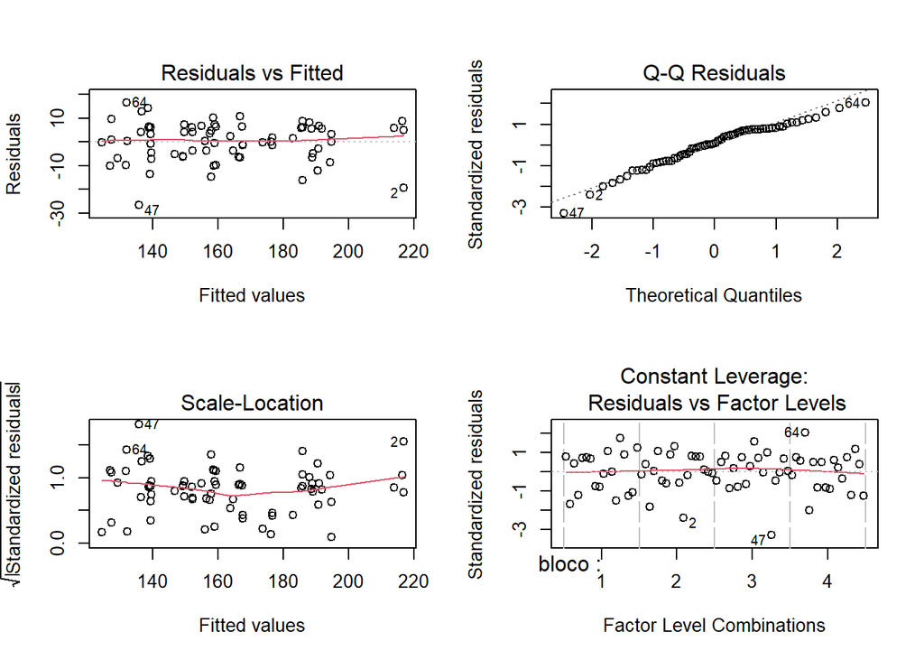

```
##
##  Shapiro-Wilk normality test
##
## data:  residuals(modelo)
## W = 0.96541, p-value = 0.04499
```

```
##
##  Bartlett test of homogeneity of variances
##
## data:  evap by interaction(acabamento, protecao, base)
## Bartlett's K-squared = 16.173, df = 17, p-value = 0.5116
```

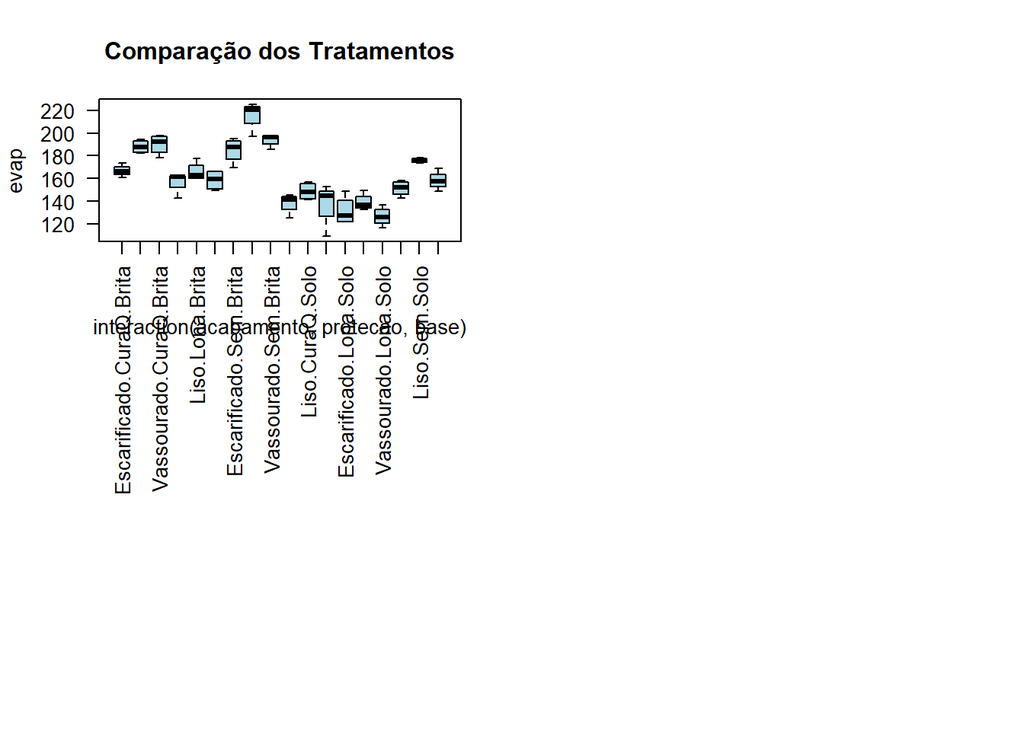

# 3 Qual o papel dos blocos neste experimento? Justifique a escolha do DBC.

Os blocos foram usados para controlar a variabilidade ambiental que poderia interferir na evaporação (diferenças de vento, temperatura e umidade em cada setor do pátio). O Delineamento em Blocos Casualizados (DBC) foi escolhido porque:

- Cada bloco contém todas as combinações de tratamentos;
- Isso permite comparar tratamentos dentro de cada bloco;
- Reduz a variabilidade residual, tornando a análise mais precisa.

# 4 Quantos tratamentos foram avaliados? Como esse número foi obtido?

Neste relatório, foram avaliados 18 tratamentos. Esse número foi obtido realizando a multiplicação dos níveis dos fatores:

3 (Acabamentos) x 3 (Proteção) x 2 (Base) = 18 Tratamentos.

# 5 A proteção com lona apresentou efeito significativo na redução da evaporação? E a cura química?

A ANOVA mostrou que o fator proteção é significativo (p < 0,05), então, sim, houve um efeito significativo na redução da evaporação.

- Sem a proteção, as médias de evaporação foram significativamente maiores;
- Utilizando a lona branca, houve redução significativa da evaporação;
- A cura química também apresentou redução na evaporação, porém se mostrou menos eficiente que a lona branca.

# 6 O tipo de base (brita ou solo) influenciou o resultado? Há evidência de interação entre base e acabamento?

O fator base teve impacto sobre a evaporação. A base de solo úmido ajudou a reduzir mais a perda de água se comparada à brita seca, já que a brita seca reflete calor, dessa forma, aquecendo a superfície do concreto.

# 7 O fator acabamento mostrou-se relevante na retenção de umidade? Em quais condições essa influência foi mais evidente?

Sim, o fator acabamento foi relevante para a retenção da umidade. Superfícies escareificadas e vassouradas tenderam a apresentar menores taxas de evaporação que o acabamento liso, porque possuem maior rugosidade e retêm um pouco mais de água.

Essa influência foi mais clara quando não havia proteção adicional (sem lona e sem cura química). Ou seja, em condições adversas (sem proteção), o acabamento teve papel decisivo.

# 8 Com base nos dados simulados, qual combinação de fatores você recomendaria para minimizar a evaporação em um dia seco e quente?

# 9 Os blocos reduziram a variabilidade residual do modelo? Como isso pode ser verificado?

# 10 Que recomendação prática pode ser feita para execução de pavimentos em áreas com diferentes tipos de base refletiva?

Com base nos dados coletados, pensemos o seguinte:

- Em áreas com brita seca, recomenda-se fortemente o uso de lona branca ou cura química para reduzir a evaporação;
- Quando se puder preparar o solo, optar pelo solo úmido compactado ajuda muito a manter a umidade;
- Mesmo com base refletiva, o acabamento escarificado é vantajoso.

Assim, a prática recomendada é combinar base úmida, proteção com lona e acabamento rugoso sempre que possível, principalmente em dias quentes e secos.

# 11 Conclusão

O experimento, como demonstrado no relatório, respondeu todas as questões sugeridas de forma satisfatória.